[figure not shown]

# Jupyter Notebook Tutorial Presentation

#### Presented by Jiahui Wei

This is a Jupyter Notebook tutorial. Presented at CMPS263 Winter 2017.

## Why Jupyter ?

You can view & run Python code (as well as other language) along with charts, graphs and take notes with Jupyter.

Jupyter is a 'Notebook' that can take notes and run code.

This presentation will include:

- execute code step by step while viewing and saving result
- use code cell to run code and visualize data with graph and charts
- use markdown cell to create notes
- share notebook with others in many ways

## 1. Jupyter Notebook Built-in Commands

### i. Use Jupyter as a terminal

```python
pwd
```

```
u'/home/wjh/Jupyter_tutorial'
```

```python
ls
```

```
Jupyter Notebook Handout.ipynb                      output_format/
Jupyter Notebook Presentation.ipynb                 README.md
Jupyter Notebook Presentation With Execution.ipynb  res4presentation/
Jupyter with Matlab example.ipynb
```

### ii View and run *.py file in Jupyter

Use

```
$ %pycat example.py
```

to view local *.py file.

Use

```
$ %run example.py
```

to run local *.py file.

```python
%pycat ./res4presentation/add_example.py
```

```python
%run ./res4presentation/add_example.py
```

```
7
```

### iii. Jupyter can write Python code into file

Use

```
$ %writefile example.py
```

to write code or text into a file.

```python
ls
```

[output not shown]

```python
%%writefile ./res4presentation/test.py
#encoding utf-8
import datetime

def print_time():
    print 'the time is:'
    print datetime.datetime.now()

print_time()
```

```
Overwriting ./res4presentation/test.py
```

```python
%pycat ./res4presentation/test.py
```

### iv. load .py file into Jupyter

Use

```
$ %load example.py
```

to load python file code into Jupyter

```python
%load ./res4presentation/test.py
```

```python
# %load ./res4presentation/test.py
#encoding utf-8
import datetime

def print_time():
    print 'the time is:'
    print datetime.datetime.now()

print_time()
```

```
the time is:
2017-02-19 23:18:35.721350
```

### v. Record the run time of the code

Use %%time to record time execution of a Python statement or expression.

```python
%%time
import time
sum=0
for x in range(100):
    sum+=x
    time.sleep(0.01)
print sum
```

```
4950
CPU times: user 8 ms, sys: 0 ns, total: 8 ms
Wall time: 1.01 s
```

Use %%timeit to record average time execution of a Python statement or expression

```python
%%timeit
import time
sum=0
for x in range(100):
    sum+=x
```

```
The slowest run took 8.90 times longer than the fastest. This could mean that an intermediate result is being cached.
100000 loops, best of 3: 3.27 µs per loop
```

## 2. Use code cell to help visualize data

Use matplotlib, pandas and other libraries with Jupyter to help visulaize data

### i. Run simple Python code

```python
1+2
```

```
3
```

```python
def add_1(x,y):
    return x+y+1
add_1(2,3)
```

```
6
```

```python
print_time()
```

```
the time is:
2017-02-19 23:18:59.970213
```

### ii. Use matplotlib to draw graph of data

Add

```
%matplotlib inline
```

to plot graph inside Jupyter

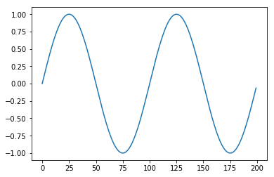

```python
%matplotlib inline
import matplotlib.pyplot as plt
import numpy as np

Fs = 200
f = 2
sample = 200
x = np.arange(sample)
y = np.sin(2 * np.pi * f * x / Fs)
plt.plot(x, y)
```

[Seaborn](http://seaborn.pydata.org/index.html) is a plotting library for Python that uses matplotlib underneath the hood. It provides for a number of plotting types that don't exist in matplotlib.

*The example used below is from [here](https://github.com/welchr/csg-jupyter-tutorial/blob/master/csg_jupyter_tutorial.ipynb)*

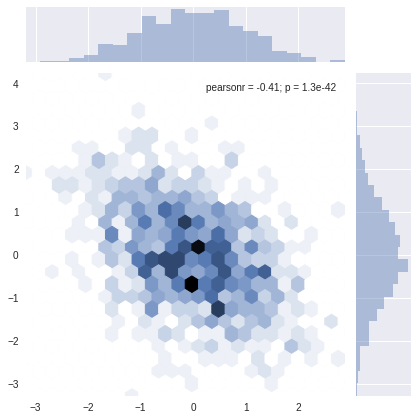

```python
%matplotlib inline
import numpy as np
from scipy.stats import kendalltau
import seaborn as sns

rs = np.random.RandomState(20)
x = rs.normal(size=1000)
y = -.5 * x + rs.normal(size=1000)

ax = sns.jointplot(x, y, kind="hex")
```

### iii. Use pandas to show the results of data frame

```python
import numpy as np
import pandas

def get_df():
    data_frame = pandas.read_csv('./res4presentation/data-text.csv', sep=',')
    return data_frame

get_df()
```

|  | Indicator | PUBLISH STATES | Year | WHO region | World Bank income group | Country | Sex | Display Value | Numeric | Low | High | Comments |
| --- | --- | --- | --- | --- | --- | --- | --- | --- | --- | --- | --- | --- |
| 0 | Life expectancy at birth (years) | Published | 1990 | Europe | High-income | Andorra | Both sexes | 77 | 77.0 | NaN | NaN | NaN |
| 1 | Life expectancy at birth (years) | Published | 2000 | Europe | High-income | Andorra | Both sexes | 80 | 80.0 | NaN | NaN | NaN |
| 2 | Life expectancy at age 60 (years) | Published | 2012 | Europe | High-income | Andorra | Female | 28 | 28.0 | NaN | NaN | NaN |
| 3 | Life expectancy at age 60 (years) | Published | 2000 | Europe | High-income | Andorra | Both sexes | 23 | 23.0 | NaN | NaN | NaN |
| 4 | Life expectancy at birth (years) | Published | 2012 | Eastern Mediterranean | High-income | United Arab Emirates | Female | 78 | 78.0 | NaN | NaN | NaN |
| 5 | Life expectancy at birth (years) | Published | 2000 | Americas | High-income | Antigua and Barbuda | Male | 72 | 72.0 | NaN | NaN | NaN |
| 6 | Life expectancy at age 60 (years) | Published | 1990 | Americas | High-income | Antigua and Barbuda | Male | 17 | 17.0 | NaN | NaN | NaN |
| 7 | Life expectancy at age 60 (years) | Published | 2012 | Americas | High-income | Antigua and Barbuda | Both sexes | 22 | 22.0 | NaN | NaN | NaN |
| 8 | Life expectancy at birth (years) | Published | 2012 | Western Pacific | High-income | Australia | Male | 81 | 81.0 | NaN | NaN | NaN |
| 9 | Life expectancy at birth (years) | Published | 2000 | Western Pacific | High-income | Australia | Both sexes | 80 | 80.0 | NaN | NaN | NaN |
| 10 | Life expectancy at birth (years) | Published | 2012 | Western Pacific | High-income | Australia | Both sexes | 83 | 83.0 | NaN | NaN | NaN |
| 11 | Life expectancy at birth (years) | Published | 2012 | Europe | High-income | Austria | Female | 83 | 83.0 | NaN | NaN | NaN |
| 12 | Life expectancy at age 60 (years) | Published | 2012 | Europe | High-income | Austria | Female | 25 | 25.0 | NaN | NaN | NaN |
| 13 | Life expectancy at birth (years) | Published | 2012 | Europe | High-income | Belgium | Female | 83 | 83.0 | NaN | NaN | NaN |
| 14 | Life expectancy at birth (years) | Published | 2000 | Eastern Mediterranean | High-income | Bahrain | Male | 73 | 73.0 | NaN | NaN | NaN |
| 15 | Life expectancy at birth (years) | Published | 1990 | Eastern Mediterranean | High-income | Bahrain | Female | 74 | 74.0 | NaN | NaN | NaN |
| 16 | Life expectancy at age 60 (years) | Published | 1990 | Eastern Mediterranean | High-income | Bahrain | Male | 17 | 17.0 | NaN | NaN | NaN |
| 17 | Life expectancy at birth (years) | Published | 2012 | Americas | High-income | Bahamas | Male | 72 | 72.0 | NaN | NaN | NaN |
| 18 | Life expectancy at age 60 (years) | Published | 2000 | Americas | High-income | Bahamas | Both sexes | 21 | 21.0 | NaN | NaN | NaN |
| 19 | Life expectancy at birth (years) | Published | 1990 | Americas | High-income | Barbados | Male | 71 | 71.0 | NaN | NaN | NaN |
| 20 | Life expectancy at age 60 (years) | Published | 2012 | Americas | High-income | Barbados | Female | 25 | 25.0 | NaN | NaN | NaN |
| 21 | Life expectancy at age 60 (years) | Published | 2012 | Americas | High-income | Barbados | Both sexes | 23 | 23.0 | NaN | NaN | NaN |
| 22 | Life expectancy at age 60 (years) | Published | 1990 | Western Pacific | High-income | Brunei Darussalam | Female | 20 | 20.0 | NaN | NaN | NaN |
| 23 | Life expectancy at age 60 (years) | Published | 2000 | Western Pacific | High-income | Brunei Darussalam | Female | 22 | 22.0 | NaN | NaN | NaN |
| 24 | Life expectancy at age 60 (years) | Published | 2012 | Western Pacific | High-income | Brunei Darussalam | Female | 21 | 21.0 | NaN | NaN | NaN |
| 25 | Life expectancy at birth (years) | Published | 2000 | Americas | High-income | Canada | Female | 82 | 82.0 | NaN | NaN | NaN |
| 26 | Life expectancy at age 60 (years) | Published | 2000 | Americas | High-income | Canada | Male | 21 | 21.0 | NaN | NaN | NaN |
| 27 | Life expectancy at age 60 (years) | Published | 1990 | Americas | High-income | Canada | Female | 24 | 24.0 | NaN | NaN | NaN |
| 28 | Life expectancy at birth (years) | Published | 1990 | Europe | High-income | Switzerland | Male | 74 | 74.0 | NaN | NaN | NaN |
| 29 | Life expectancy at birth (years) | Published | 2012 | Europe | High-income | Switzerland | Both sexes | 83 | 83.0 | NaN | NaN | NaN |
| ... | ... | ... | ... | ... | ... | ... | ... | ... | ... | ... | ... | ... |
| 4626 | Healthy life expectancy (HALE) at birth (years) | Published | 2012 | Europe | Upper-middle-income | Serbia | Female | 67 | 67.0 | NaN | NaN | NaN |
| 4627 | Healthy life expectancy (HALE) at birth (years) | Published | 2012 | Americas | Upper-middle-income | Suriname | Both sexes | 66 | 66.0 | NaN | NaN | NaN |
| 4628 | Healthy life expectancy (HALE) at birth (years) | Published | 2012 | Europe | High-income | Sweden | Both sexes | 72 | 72.0 | NaN | NaN | NaN |
| 4629 | Healthy life expectancy (HALE) at birth (years) | Published | 2012 | Africa | Lower-middle-income | Swaziland | Female | 47 | 47.0 | NaN | NaN | NaN |
| 4630 | Healthy life expectancy (HALE) at birth (years) | Published | 2000 | Africa | Upper-middle-income | Seychelles | Male | 61 | 61.0 | NaN | NaN | NaN |
| 4631 | Healthy life expectancy (HALE) at birth (years) | Published | 2000 | Eastern Mediterranean | Lower-middle-income | Syrian Arab Republic | Female | 64 | 64.0 | NaN | NaN | NaN |
| 4632 | Healthy life expectancy (HALE) at birth (years) | Published | 2012 | Africa | Low-income | Chad | Female | 44 | 44.0 | NaN | NaN | NaN |
| 4633 | Healthy life expectancy (HALE) at birth (years) | Published | 2000 | South-East Asia | Lower-middle-income | Thailand | Male | 59 | 59.0 | NaN | NaN | NaN |
| 4634 | Healthy life expectancy (HALE) at birth (years) | Published | 2000 | South-East Asia | Lower-middle-income | Thailand | Female | 65 | 65.0 | NaN | NaN | NaN |
| 4635 | Healthy life expectancy (HALE) at birth (years) | Published | 2000 | Europe | Low-income | Tajikistan | Both sexes | 56 | 56.0 | NaN | NaN | NaN |
| 4636 | Healthy life expectancy (HALE) at birth (years) | Published | 2012 | Europe | Low-income | Tajikistan | Female | 60 | 60.0 | NaN | NaN | NaN |
| 4637 | Healthy life expectancy (HALE) at birth (years) | Published | 2012 | Western Pacific | Lower-middle-income | Tonga | Female | 61 | 61.0 | NaN | NaN | NaN |
| 4638 | Healthy life expectancy (HALE) at birth (years) | Published | 2012 | Americas | High-income | Trinidad and Tobago | Female | 64 | 64.0 | NaN | NaN | NaN |
| 4639 | Healthy life expectancy (HALE) at birth (years) | Published | 2012 | Americas | High-income | Trinidad and Tobago | Both sexes | 61 | 61.0 | NaN | NaN | NaN |
| 4640 | Healthy life expectancy (HALE) at birth (years) | Published | 2000 | Eastern Mediterranean | Lower-middle-income | Tunisia | Male | 63 | 63.0 | NaN | NaN | NaN |
| 4641 | Healthy life expectancy (HALE) at birth (years) | Published | 2012 | Western Pacific | Upper-middle-income | Tuvalu | Male | 57 | 57.0 | NaN | NaN | NaN |
| 4642 | Healthy life expectancy (HALE) at birth (years) | Published | 2000 | Africa | Low-income | Uganda | Female | 40 | 40.0 | NaN | NaN | NaN |
| 4643 | Healthy life expectancy (HALE) at birth (years) | Published | 2000 | Europe | Lower-middle-income | Ukraine | Both sexes | 60 | 60.0 | NaN | NaN | NaN |
| 4644 | Healthy life expectancy (HALE) at birth (years) | Published | 2012 | Americas | Upper-middle-income | Uruguay | Male | 65 | 65.0 | NaN | NaN | NaN |
| 4645 | Healthy life expectancy (HALE) at birth (years) | Published | 2012 | Americas | Upper-middle-income | Uruguay | Female | 70 | 70.0 | NaN | NaN | NaN |
| 4646 | Healthy life expectancy (HALE) at birth (years) | Published | 2012 | Americas | Upper-middle-income | Uruguay | Both sexes | 68 | 68.0 | NaN | NaN | NaN |
| 4647 | Healthy life expectancy (HALE) at birth (years) | Published | 2000 | Americas | Upper-middle-income | Saint Vincent and the Grenadines | Both sexes | 61 | 61.0 | NaN | NaN | NaN |
| 4648 | Healthy life expectancy (HALE) at birth (years) | Published | 2012 | Americas | Upper-middle-income | Venezuela (Bolivarian Republic of) | Both sexes | 66 | 66.0 | NaN | NaN | NaN |
| 4649 | Healthy life expectancy (HALE) at birth (years) | Published | 2000 | Western Pacific | Lower-middle-income | Vanuatu | Male | 59 | 59.0 | NaN | NaN | NaN |
| 4650 | Healthy life expectancy (HALE) at birth (years) | Published | 2012 | Western Pacific | Lower-middle-income | Samoa | Male | 62 | 62.0 | NaN | NaN | NaN |
| 4651 | Healthy life expectancy (HALE) at birth (years) | Published | 2012 | Western Pacific | Lower-middle-income | Samoa | Female | 66 | 66.0 | NaN | NaN | NaN |
| 4652 | Healthy life expectancy (HALE) at birth (years) | Published | 2012 | Eastern Mediterranean | Low-income | Yemen | Both sexes | 54 | 54.0 | NaN | NaN | NaN |
| 4653 | Healthy life expectancy (HALE) at birth (years) | Published | 2000 | Africa | Upper-middle-income | South Africa | Male | 49 | 49.0 | NaN | NaN | NaN |
| 4654 | Healthy life expectancy (HALE) at birth (years) | Published | 2000 | Africa | Low-income | Zambia | Both sexes | 36 | 36.0 | NaN | NaN | NaN |
| 4655 | Healthy life expectancy (HALE) at birth (years) | Published | 2012 | Africa | Low-income | Zimbabwe | Female | 51 | 51.0 | NaN | NaN | NaN |

4656 rows × 12 columns

## 3. Use markdown cell to keep notes

There is a example of a markdown below.

# A First Level Headline

Use *word* to show *Italic*

Use **word** to show **bold**.

Itemized lists look like:

- this one
- that one

Here's a numbered list:

1. first item
2. second item
3. third item

## A Second Level Headline

You can add code block into the cell like this:

This is a python code block

```
import time
# Quick, count from 0 to 9!
for i in range(10):
    # wait for a while
    time.sleep(0.5)
    print i
```

This is a C++ code block

```
#include<iostream>
usig namespace std;
int main(){
cout<<"Hello World!"<<endl;
}
```

### A Third Level Headline

Here's a link to [a website](http://www.ucsc.edu), to a local file.

Inline math equations go in like so: $\int_0^{+\infty} x^2 dx$. Display math should get its own line and be put in in double-dollarsigns: $$\int_0^{+\infty} x^2 dx$$ Images can also be added into markdown cell

[figure not shown]

*Markdown example used from [here](http://www.unexpected-vortices.com/sw/rippledoc/quick-markdown-example.html#an-h2-header) with some edits*

# A First Level Headline

Use *word* to show *Italic*

Use **word** to show **bold**.

Itemized lists look like:

- this one
- that one

Here's a numbered list:

1. first item
2. second item
3. third item

### ii. Code Block

Code block can be highlighted according to the language

This is a python code block

```
import time
# Quick, count from 0 to 9!
for i in range(10):
    # wait for a while
    time.sleep(0.5)
    print i
```

This is a C++ code block

```
#include<iostream>
usig namespace std;
int main(){
cout<<"Hello World!"<<endl;
}
```

### iii. Links

Link to offline Pictures

[Link to online website](http://www.ucsc.edu)

Another type of link http://www.ucsc.edu

### iv. Latex

Latex can also be used in Jupyter to write math expression

This is an expression as a single expression $$\int_0^2 x^2 dx$$

Inline expression is also supported, for example, $\int^2_0 x^2 dx$

### v. Images

Images can be added like links.

[figure not shown]

We can use HTML style to edit image size and position

[figure not shown]

### vi. Video

We can also add videos in Jupyter

```python
%%html
<iframe width="560" height="315" src="https://www.youtube.com/embed/HW29067qVWk" frameborder="0" allowfullscreen></iframe>
```

[video not shown]

## 4. Export *.ipynb file to other formats to share with others

### i. Github

Github can load *.ipynb file, here is [example1](https://github.com/jhwei/Jupyter_Tutorial/blob/master/Jupyter%20Notebook%20Presentation.ipynb) and [example2](https://github.com/jhwei/Jupyter_Tutorial/blob/master/Jupyter%20Notebook%20Presentation%20With%20Execution.ipynb)

### ii. Export to other formats

Goto **File**->**Download as** to select the file format you want to export to.

Or you can type the following command in terminal

```
$ jupyter nbconvert --to FORMAT notebook.ipynb
```

- FORMAT means the file format you want to export to, such as, pdf, html
- you may need to install latex and other software depending on your computer
- please refer to the error to see if some software is missing if you don't succeed

### iii. Several useful format

- An example of html without execution and html with execution
- An example of pdf (using nbconvert) and pdf (convert from html)
- An example of py

## 5. Useful Resources

Offical Documentation https://jupyter.readthedocs.io/en/latest/index.html

Markdown syntx Document from Github https://guides.github.com/features/mastering-markdown/

Jupyter with other programming languages https://github.com/jupyter/jupyter/wiki/Jupyter-kernels

Some nice Jupyter examples http://nb.bianp.net/sort/views/

Another good Jupyter tutorial https://github.com/welchr/csg-jupyter-tutorial

Turn Jupyter to presentation slides with RISE https://github.com/damianavila/RISE

Combine Jupyter with WordPress http://www.mianchen.com/wordpress-blogging-with-jupyter-notebook-in-five-simple-steps/